# 正则化及其R实现

余文华

2016年4月22日

## 文前说明

```
本文是最近学习正则化的网络资源的总结，主要是总结和方便个人学习。
```

## 模型的变量选择

```
在变量选择方面有三种扩展的方法：
```

1. 子集选择：这是传统的方法，包括逐步回归和最优子集法等，对可能的部分子集拟合线性模型，利用判别准则 （如AIC,BIC,Cp,调整R2 等）决定最优的模型。
2. 收缩方法（shrinkage method）：又称为正则化（regularization）。主要是岭回归（ridge regression）和lasso回归(least absolute shrinkage and selection operator),读音不是[‘l??so]而是[l??’su:]。通过对最小二乘估计加入罚约束，使某些系数的估计为0。
3. 维数缩减：主成分回归（PCR）和偏最小二乘回归（PLS）的方法。把p个预测变量投影到m维空间（m<p），利用投影得到的不相关的组合建立线性模型。

我们这期主要来学习和总结下正则化方法。

## 正则化(regularization)

[output not shown]

## R语言实现

```
glmnet包是关于Lasso and elastic-net regularized generalized linear models。 作者是Friedman, J., Hastie, T. and Tibshirani。这个包采用的算法是循环坐标下降算法（cyclical coordinate descent）： 对每一个参数在保持其它参数固定的情况下进行优化，循环，直到系数稳定为止。这个计算是在lambda的格点值上进行的。 关于这个算法见[2]。 关于glmnet包的细节可参考[1]。
```

### glmnet举例

```
我们使用mlbench包中的Sonar数据集，来模拟Logistic回归，通过60个声纳信号变量预测所采的岩石是否为矿石。先建立train集和test集，运用glmnet包实现：参数alpha=1为lasso回归，alpha=0为岭回归。
```

#### 岭回归

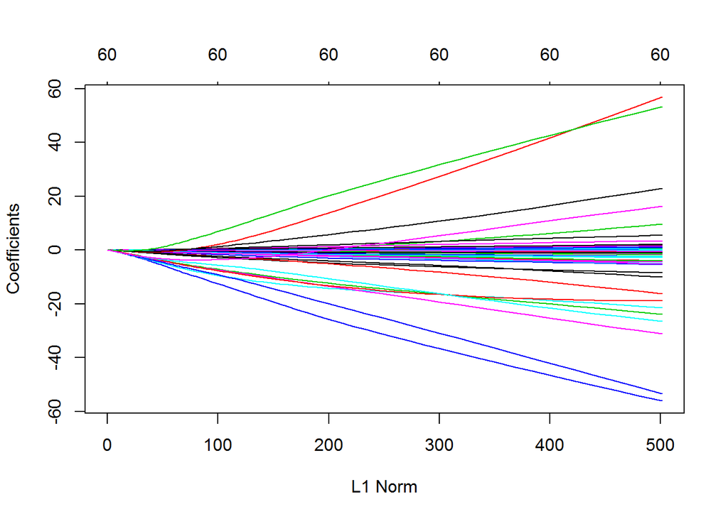

```r
library(glmnet)
require(mlbench)
data(Sonar)
set.seed(123)
train.index = sample(nrow(Sonar), 0.7 * nrow(Sonar))
train.x = as.matrix(Sonar[train.index, 1:60]);
train.y = Sonar[train.index, 61];
test.x = as.matrix(Sonar[-train.index,1:60]);
test.y = Sonar[-train.index, 61]
r1 <- glmnet(train.x,train.y,family = "binomial",alpha = 0)
plot(r1)
```

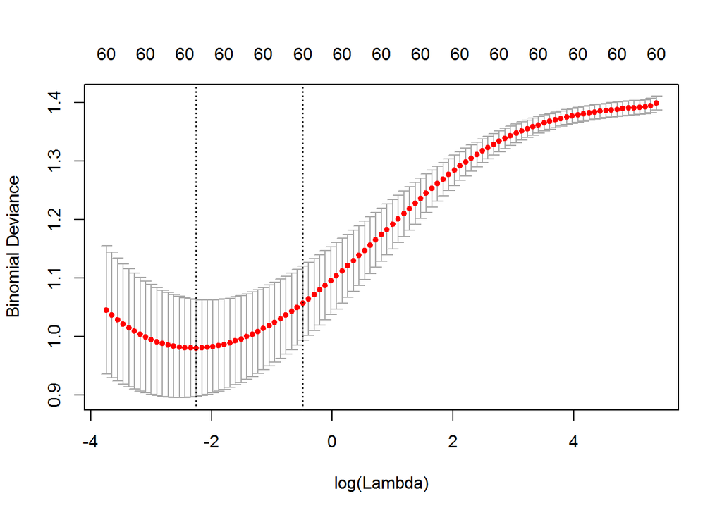

```r
r1.cv <- cv.glmnet(train.x,train.y,family = "binomial",alpha = 0,nfolds = 10)
plot(r1.cv)
```

#### Lasso回归

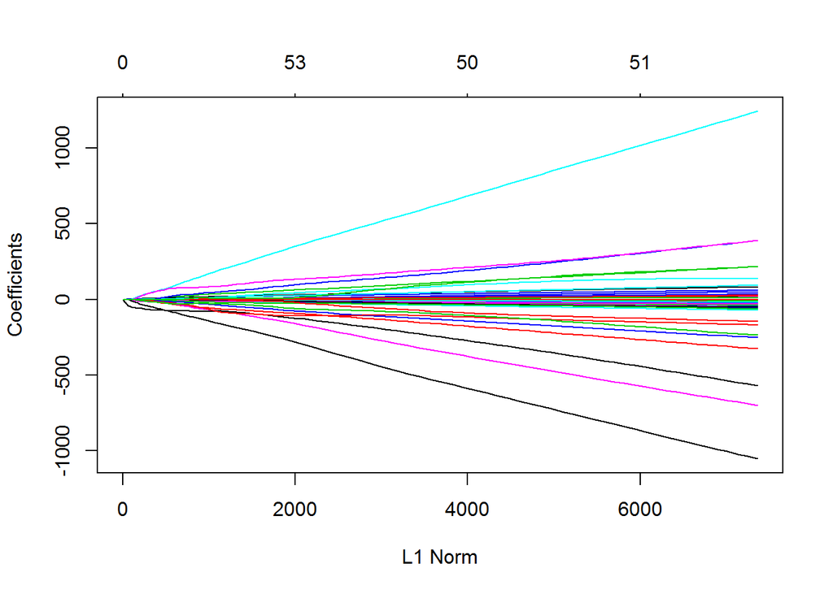

```r
r2 <- glmnet(train.x,train.y,family = "binomial",alpha = 1)
plot(r2)
```

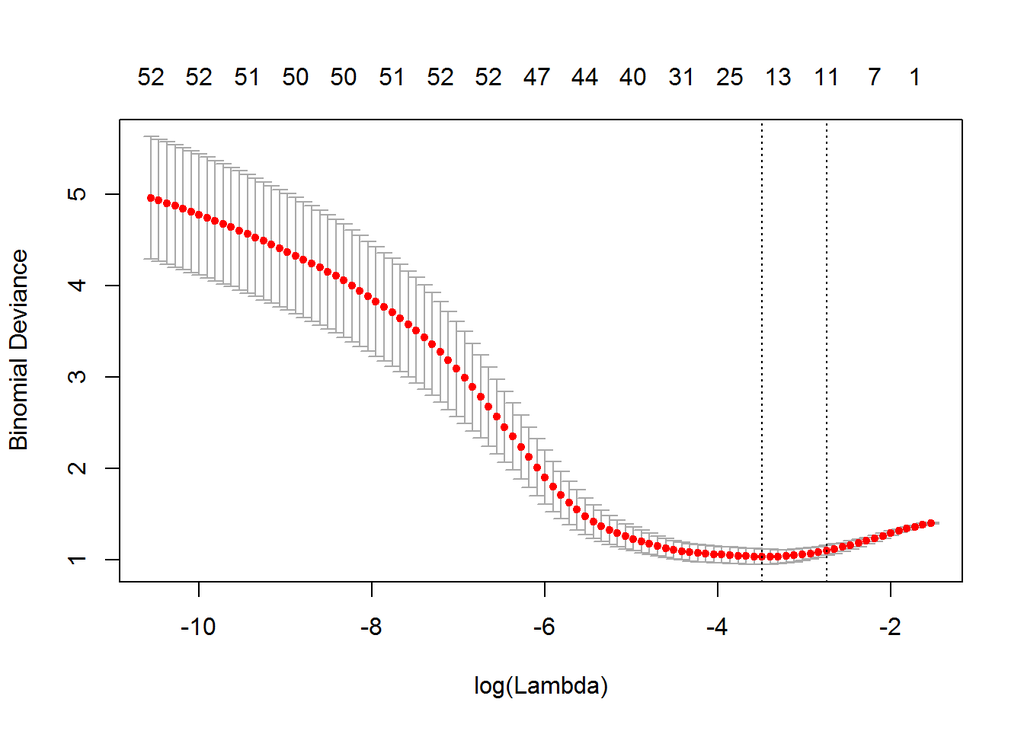

[output not shown]

```r
r2.cv <- cv.glmnet(train.x,train.y,family = "binomial",alpha = 1,nfolds = 10)
plot(r2.cv)
```

```r
r2.cv$lambda.min
```

```
## [1] 0.03057333
```

```r
r2.cv$lambda.1se
```

```
## [1] 0.06435394
```

```
根据获取的lambda.min及lambda.1se,获取变量个数及其对应的系数：
```

```r
#lambda.1se 模型
r2.1se <- glmnet(train.x,train.y, family = "binomial", alpha = 1, lambda = r2.cv$lambda.1se)
r2.min_coef <- coef(r2.1se)
r2.min_coef[which(r2.min_coef != 0)]
```

```
##  [1]   2.528653460  -1.375896057  -2.182518459  -2.318613495  -0.007801761
##  [6]  -1.082833807   0.436604899  -0.479280361  -1.568847126  -2.211063523
## [11]  -0.409219202 -28.526987640
```

```r
rownames(r2.min_coef)[which(r2.min_coef != 0)]
```

```
##  [1] "(Intercept)" "V4"          "V11"         "V12"         "V20"
##  [6] "V21"         "V36"         "V44"         "V45"         "V47"
## [11] "V49"         "V52"
```

```r
#lambda.min 模型
r2.min <- glmnet(train.x,train.y, family = "binomial", alpha = 1, lambda = r2.cv$lambda.min)
r2.min_coef <- coef(r2.min)
r2.min_coef[which(r2.min_coef != 0)]
```

```
##  [1]   3.931356168  -3.039014423   0.403657159  -3.035227924  -2.969295251
##  [6]   0.303027594   0.095894825  -0.245114159  -1.386320941  -0.320898264
## [11]  -0.131836323   0.006336814   0.384432072   1.374859288  -2.982805613
## [16]  -2.306124901  -3.167529057  -0.761401320  -2.074506505 -46.855128167
## [21]  -5.064733714
```

```r
rownames(r2.min_coef)[which(r2.min_coef != 0)]
```

```
##  [1] "(Intercept)" "V4"          "V7"          "V11"         "V12"
##  [6] "V15"         "V16"         "V20"         "V21"         "V22"
## [11] "V24"         "V31"         "V34"         "V36"         "V44"
## [16] "V45"         "V47"         "V49"         "V51"         "V52"
## [21] "V58"
```

#### lambda的选取

```
lambda.min：value of lambda that gives minimum cvm.lambda.1se：largest value of lambda such that error is within 1 standard error of the minimum.网上的讨论推荐使用lambda.1se的比较多，这样可以得到更简洁的模型。.但是还有这样的说法：1se在低noise的时候才好用，高noise的时候，有一两个fold的error很大，cv curve就会增长很快，导致选的lambda太大。
```

#### 模型评价

```r
lasso.pred <- predict(r2, s = r2.cv$lambda.1se, newx = test.x,type = "class")
#模型正确率
(length(which(lasso.pred==test.y)==TRUE))/length(test.y)*100
```

```
## [1] 73.01587
```

### 岭回归和lasso的比较

```r
lasso.pred <- predict(r2, s = r2.cv$lambda.1se, newx = test.x,type = "class")
ridge.pred <- predict(r1, s = r1.cv$lambda.1se, newx = test.x,type = "class")
#正确率
(length(which(lasso.pred==test.y)==TRUE))/length(test.y)*100
```

```
## [1] 73.01587
```

```r
(length(which(ridge.pred==test.y)==TRUE))/length(test.y)*100
```

```
## [1] 69.84127
```

```
如果你的数据变异较大，那么在做LASSO之前最好进行数据标准化处理。LASSO的进一步扩展是和岭回归相结合，形成Elastic.Net方法。glmnet包也可以实施这种算法。glmnet算法需将分析数据转换为矩阵，这要求分析数据类型都为numeric类型，因此对于既有double类型也有factor类型的数据，需先将有factor类型转换为0-1哑变量类型。同时在glmne中，运用dfmax参数可控制特征选择的个数。
```

### 材料补充

#### 对glmnet的一个封装，可以直接用来筛选变量

```
肖楠大侠通过SuperLearner::screen.glmnet对glmnet的一个封装，可以直接用来筛选变量。
```

```r
library(glmnet)
ScreenLasso = function (Y, X, family, nlambda = 100, alpha = 1,
                         minscreen = 2, nfolds = 10, ...) {
  require(glmnet)
  if (!is.matrix(X)) X = model.matrix(~-1 + ., X)
  fitCV = cv.glmnet(x = X, y = Y, lambda = NULL, type.measure = "deviance",
                    nfolds = nfolds, family = family, alpha = alpha,
                    nlambda = nlambda, ...)
  whichVariable = (as.numeric(coef(fitCV$glmnet.fit,
                                   s = fitCV$lambda.min))[-1] != 0)
  if (sum(whichVariable) < minscreen) {
    warning("fewer than minscreen variables passed the glmnet screen,
            increased lambda to allow minscreen variables")
    sumCoef = apply(as.matrix(fitCV$glmnet.fit$beta), 2,
                    function(x) sum((x != 0)))
    newCut  = which.max(sumCoef >= minscreen)
    whichVariable = as.matrix(fitCV$glmnet.fit$beta)[, newCut] != 0
  }
  return(whichVariable)
}
```

#### 封装函数预测，自动选择变量

```r
require(mlbench)
data(Sonar)
Selected = ScreenLasso(Y = Sonar[, 61], X = Sonar[, -61], family = 'binomial',
                       nlambda = 50, minscreen = 10, nfolds = 10)
SonarSelected = Sonar[, Selected]
```

## 参考资料

> [1]Friedman,J.,Hastie,T.,Tibshirani.R.:Regularization Paths for Generalized Linear Models via Coordinate Descent.Journal of Statistical Software,Volume 33(2010), Issue 1.

> [2]J. Friedman, T. Hastie, H. Hoe ing, and R. Tibshirani.:Pathwise coordinate optimization. Annals of Applied Statistics, 2(1):302-332, 2007. http://www.stanford.edu/~hastie/Papers/pathwise.pdf

> 用glmnet包实施套索算法(LASSO) http://www.tuicool.com/articles/Vna6J3 统计之都 http://cos.name/cn/topic/105760/;http://cos.name/cn/topic/109084/ 统计学习那些事 http://cos.name/2011/12/stories-about-statistical-learning/ 豆瓣 数据铺子：线性回归建模–变量选择和正则化https://site.douban.com/182577/widget/notes/10567212/note/288551448/ Coursera:machine learning,Andrew Ng https://www.coursera.org/learn/machine-learning/home/welcome 机器学习之正则化（Regularization）http://doc.okbase.net/jianxinzhou/archive/111322.html